# Making Your Own R Package

will transform your life | [EFB 654: R and Reproducible Research](https://eligurarie.github.io/EFB654/)

Elie Gurarie

2026-04-13

# Why build an R package?

Building your own R package is one of the most powerful habits you can develop as an R programmer. It lets you:

- Conquer and permanently tame confusing folder soups of data and R scripts
- Make code **ultra-compact**, **well-documented**, and **highly replicable**
- Dramatically shorten the time it takes to get back on track after a break from a project

And ultimately, to truly publish (i.e. make public and available) your tools and methods in a form others can install and use. In particular by uploading to [CRAN](https://cran.r-project.org/web/packages/available_packages_by_date.html) or other repositories.

## A motivating example: Sonoran Pronghorn

Here’s a concrete example: I helped out on an analysis of data from an intense conservation effort for Sonoran pronghorn (*Antilocapra americana sonoriensis*). These are highly endangered (at one point a few dozen in the wild), and a core portion of their range overlaps with a large artillery range in Arizona. Data have been collected, in large part by the Army Corps of Engineers, and was sent to me in a hard drive with thousands of files. It was a total mess. But we got through it and eventually published a paper ([Barbour et al 2024](https://wildlife.onlinelibrary.wiley.com/doi/full/10.1002/jwmg.22675)).

Here are some pronghorn:

[figure not shown]

### Processing data

Below is a small snippet of a data processing step:

```r
gps.dir <- "data/SonoranPronghorn/Locations_GPSCollarTelemetry/"
pronghorn <- read.csv(paste0(gps.dir, f.v1[i])) %>%
  processRaw_v1(id = id.v1[i], filename = f.v1[i])

pronghorn.sf <- st_as_sf(df.raw,
    coords = c("ECEF_X..m.", "ECEF_Y..m.", "ECEF_Z..m.")) %>%
  st_set_crs(4978) %>% st_transform(4326) %>% st_coordinates

with(df.raw,
     data.frame(
       File     = filename,
       ID       = CollarID,
       DateTime = mdy_hms(paste(UTC_Date, UTC_Time)),
       Latitude = ll[,"Y"],
       Longitude = ll[,"X"],
       Elevation = ll[,"Z"])) %>%
  subset(!is.na(DateTime))

# important: need to convert from windows-1252 to UTF8 in order to read:
#  find *.csv -exec sh -c "iconv -f Windows-1252 -t UTF8 {} > {}v2" \;

f.v2 <- f[grepl("GPS_Collar", f)]

pronghorn_gps_v2 <- data.frame()
for(i in 1:length(f.v2)){
  if(f.v2[i] != badf){
    print(f.v2[i])
    df <- read.csv(paste0(gps.dir, "encoded/", f.v2[i])) %>%
      subset(!is.na(ECEF_X..m.)) %>%
      processRaw_v2(filename = f.v2[i])
    pronghorn_gps_v2 <- rbind(pronghorn_gps_v2, df)
  }
}
```

That’s a lot of fussy code to keep track of and replicate.

But once the data and functions are bundled into a package, the entire workflow reduces to:

```r
require(pronghorn)
data("pronghorn_gps")
str(pronghorn_gps)
```

```
## 'data.frame':    25184 obs. of  6 variables:
##  $ File     : chr  "GPS_Collar_28269_Animal_NA_LastDataPullDate_20180822.csv" "GPS_Collar_28269_Animal_NA_LastDataPullDate_20180822.csv" "GPS_Collar_28269_Animal_NA_LastDataPullDate_20180822.csv" "GPS_Collar_28269_Animal_NA_LastDataPullDate_20180822.csv" ...
##  $ ID       : Factor w/ 43 levels "451","F_61_8251",..: 25 25 25 25 25 25 25 25 25 25 ...
##  $ DateTime : POSIXct, format: "2017-12-07 02:00:12" "2017-12-07 13:00:38" ...
##  $ Latitude : num  32.4 32.4 32 32 32 ...
##  $ Longitude: num  -113 -113 -113 -113 -113 ...
##  $ Elevation: num  458 451 583 530 538 ...
```

It all just there. And the accompanying help file contains all the infromation about these data, as well as handy code (directly in the help file) to visualize.

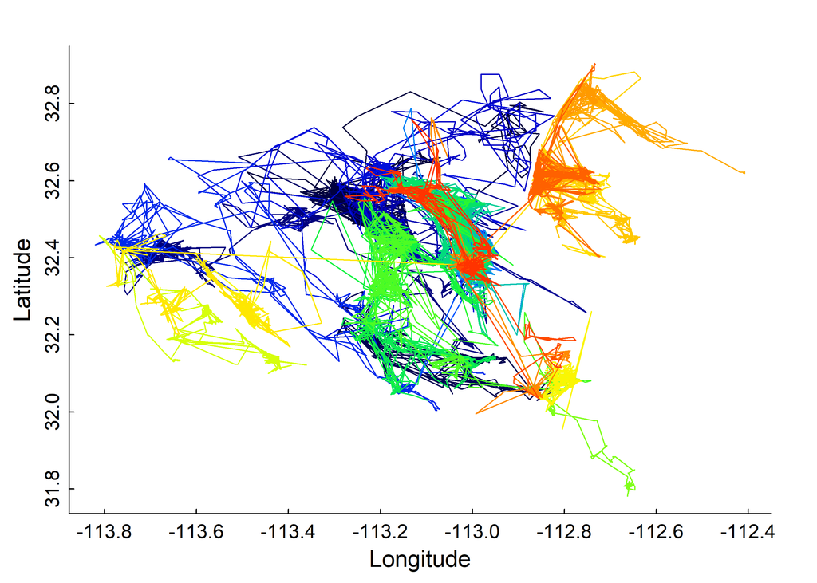

```r
 require(gplots)
  cols <- rich.colors(length(unique(pronghorn_gps$ID)))
  with(pronghorn_gps, plot(Longitude, Latitude, type = "n"))
  d_ply(pronghorn_gps, "ID", function(df) lines(df$Longitude, df$Latitude, col = cols[as.integer(df$ID[1])]))
```

Note the other datasets here:

```r
data(package = "pronghorn")
```

```
Data sets in package ‘pronghorn’:

burn (pronghorn_shapefiles)

enclosure (pronghorn_shapefiles)

forage_plots (pronghorn_shapefiles)

home_range (pronghorn_shapefiles)

homerange                 Area-Corrected AKDE Home Ranges for Processed,
                          Regularized GPS data of Sonoran Pronghorn
landscape                 Landscape data for the BMGR
observation_points (pronghorn_shapefiles)

pronghorn_aerial          Pronghorn Aerial Observations
pronghorn_ctmm_edited     Processed, regularized GPS data of Sonoran pronghorn
pronghorn_flight          Pronghorn Flight Observations
pronghorn_gps             GPS data of Sonoran pronghorn
pronghorn_gps_new
pronghorn_ground          Pronghorn Ground Observations
pronghorn_ground_all      Pronghorn Ground Observations - All Years
                          (1997-2020)
pronghorn_ground_early    Pronghorn Ground Observations - Early Years
                          (2003-2007)
pronghorn_mortality_sex   Pronghorn GPS Collar Mortality and Sex Data
pronghorn_wild            Ground observations of wild pronghorn
recovery_pen (pronghorn_shapefiles)
                          Shape files
semicaptive_enclosures (pronghorn_shapefiles)

targets                   Target practice data from USAF
wildlife_water (pronghorn_shapefiles)
```

## R package structure

In a nutshell, an R package is a folder with a specific structure that R knows how to install, load, and document. The key components are:

- `R/` — contains your R function scripts
- `data/` — contains datasets saved as `.rda` files
- `man/` — contains documentation (auto-generated by Roxygen)
- `DESCRIPTION` — a plain-text file with essential metadata about the package
- `NAMESPACE` — a file that controls which functions, data and other opjects are exported (*mainly automated*)

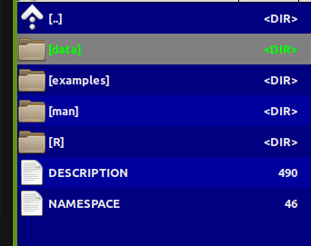

Package folder structure

### The `DESCRIPTION` file

The `DESCRIPTION` file is a plain-text file that lives in the root of your package directory and contains essential metadata. It is required — a folder without a valid `DESCRIPTION` is not a package. Below is the one from our internal Sonoran pronghorn project:

```
Package: pronghorn
Type: Package
Title: Sonoran pronghorn analysis project
Version: 0.1.0
Author: Elie, Nicki, others
Maintainer: The package maintainer <yourself@somewhere.net>
Description: The pronghorn package is a PRIVATE collaborative package
             containing processed data, code and results for analysis
             of Sonoran pronghorn.
License: PRIVATE
Encoding: UTF-8
LazyData: false
Depends: lubridate, magrittr, plyr, dplyr, ggplot2, ggpubr, sp, sf, stringr
Suggests: mapview
RoxygenNote: 7.1.1
```

The key fields:

- **`Package`** — the name of your package, no spaces. This is what goes inside `library()`.
- **`Title`** — a short, human-readable one-liner. Used in documentation indexes.
- **`Version`** — follows `major.minor.patch` convention (e.g., `0.1.0`). Increment this when you make changes, especially if others depend on your package.
- **`Author` / `Maintainer`** — who wrote it and who to contact about it. For a personal or small-team package these can be the same person.
- **`Description`** — a paragraph describing what the package does. Required for CRAN submission; for private packages it’s just good practice.
- **`License`** — how others may use your code. Common choices are `GPL-3`, `MIT`, or `CC BY 4.0`. For a private internal package, `PRIVATE` is a reasonable placeholder that signals it is not for redistribution.
- **`Depends`** — packages that must be installed and *attached* (i.e., loaded via `library()`) for yours to work. Use sparingly — everything listed here gets loaded automatically when someone loads your package, which can cause conflicts.
- **`Imports`** (not shown above, but worth knowing) — packages your code calls but that don’t need to be fully attached. Preferred over `Depends` for most dependencies.
- **`Suggests`** — packages that are useful but not required (e.g., for running examples or vignettes).
- **`Encoding`** — almost always `UTF-8`.
- **`LazyData`** — if `true`, datasets are only loaded into memory when first accessed rather than at `library()` time. Fine to leave `true` for most packages; set to `false` if your data loading has side effects.
- **`RoxygenNote`** — automatically updated by `roxygen2` to record which version generated the documentation. Don’t edit this by hand.

### Documentation and Roxygen

R package documentation lives in the `man/` folder as `.Rd` files. These are auto-generated from specially formatted comments in your R scripts using the `roxygen2` package. For example, the Roxygen comment block for a dataset looks like this:

```r
#' GPS data of Sonoran pronghorn
#'
#' 43 GPS collared pronghorn collared between 2008 and 2020
#'
#' @usage data(pronghorn_gps)
#'
#' @format Contains only five columns:
#' \describe{
#'   \item{File}{Original file name}
#'   \item{ID}{ID of animal}
#'   \item{DateTime}{Date and time in POSIXct}
#'   \item{Longitude,Latitude}{}
#' }
#' @example examples/pronghorn_gps_examples.R
#' @source Arizona DFG, via Andy Goodwin.
#' @keywords data
```

Every comment line begins with `#'`. When you build the package, Roxygen converts these blocks into the `.Rd` help files that appear when you run `?pronghorn_gps`.

# How to create a package

There are four main approaches:

1. By hand (not recommended)
2. `base::package.skeleton()`
3. `usethis::create_package()` ← **recommended**
4. Build directly off an existing GitHub project

## Step-by-step: building the `combinator` package

To make this concrete, we will take the functions in `fittingfunctions.R` and the datasets `single.csv` and `mixture.csv` and bundle them into a package called `combinator`.

The package fits a logistic growth model and allows exploration of a classic two-species competition experiment by Georgi Gause (1934). The data show the population growth of *Paramecium aurelia* and *P. caudatum* grown separately and together.

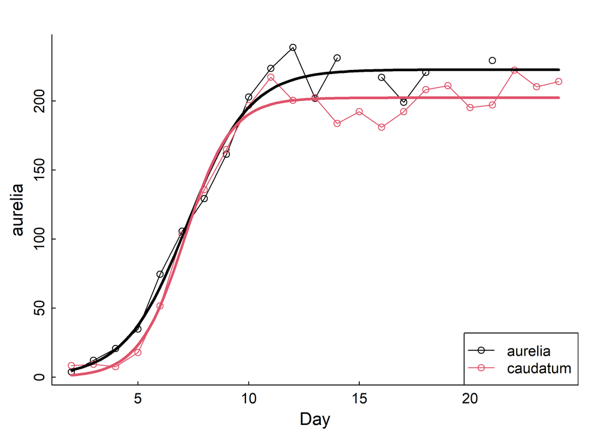

### Step I: Build a skeleton (empty) package

First, know your working directory — your package will be created as a subfolder of it.

```r
getwd()
```

```
## [1] "C:/Users/egurarie/teaching/EFB654/lectures/22-Rpackages"
```

If you are on Windows and have not done so already, install the Rtools compilation bundle:

```r
installR::install.Rtools()
```

Then create the package skeleton using `usethis`:

```r
require(usethis)
create_package("combinator")
```

This creates a `combinator/` folder with the correct structure and opens a new RStudio project inside it. You need to be working inside that project for the build tools to work correctly. The initial `DESCRIPTION` file will look like:

```
Package: combinator
Title: What the Package Does
Version: 0.0.0.9000
Authors@R (parsed):
  * First Last <first.last@example.com> [aut, cre]
Description: What the package does.
License: use_mit_license() or friends
Encoding: UTF-8
LazyData: true
RoxygenNote: 7.1.0
```

### Step II: Edit the `DESCRIPTION` file

Open `DESCRIPTION` and fill in your name, a title, a brief description, and a license. A convenient way to set the license is:

```r
use_gpl3_license("combinator")
```

which produces:

```
✓ Setting active project to '.../combinator'
✓ Setting License field in DESCRIPTION to 'GPL-3'
✓ Writing 'LICENSE.md'
✓ Adding '^LICENSE\.md$' to '.Rbuildignore'
```

For a personal-use package, the license choice is not critical, but it is good practice.

### Step III: Save some data

Read the two data files and save them into the package `data/` directory using the `.rda` format:

```r
single  <- read.csv("content/single.csv")
mixture <- read.csv("content/mixture.csv")

save(single,  file = "data/single.rda")
save(mixture, file = "data/mixture.rda")
```

The `.rda` format is R’s native binary format. You can always load these files directly (outside of the package context) with:

```r
load("data/single.rda")
load("data/mixture.rda")
```

### Step IV: Save some code

Take the following three functions from `fittingfunctions.R` and save each into a **separate** `.R` file in the `R/` directory: `logistic.R`, `fitLogistic.R`, and `linesLogistic.R`. Separating functions into individual files is cleaner and better practice than putting everything in one file.

```r
logistic <- function(x, N0, K, r0){
  K / (1 + ((K - N0) / N0) * exp(-r0 * x))
}

fitLogistic <- function(data, y = "N", time = "Day",
                        N0 = 1, K = 200, r0 = 0.75){
  Y <- with(data, get(y))
  X <- with(data, get(time))
  myfit <- nls(Y ~ logistic(X, N0, K, r0),
               start = list(N0 = N0, K = K, r0 = r0))
  summary(myfit)
}

linesLogistic <- function(au.fit, ...){
  curve(logistic(x,
    N0 = au.fit$coefficients[1,1],
    K  = au.fit$coefficients[2,1],
    r0 = au.fit$coefficients[3,1]), add = TRUE, ...)
}
```

### Step V: Set up and use Roxygen documentation

Roxygen2 allows you to write documentation as structured comments directly in your function scripts, which are then automatically converted into help files when you build the package.

First, install the package:

```r
install.packages("roxygen2")
```

Then, in RStudio, go to `Build > Configure Build Tools`, click `Configure`, and check the box next to `Build and Restart` to enable Roxygen.

Now modify `logistic.R` to add a documentation block above the function:

```r
#' Logistic function
#'
#' Computes the logistic growth function, which grows from an initial value
#' toward a carrying capacity K.
#'
#' @param x time
#' @param N0 initial population size
#' @param K carrying capacity
#' @param r0 intrinsic growth rate
#' @examples curve(logistic(x, .01, 1, 10))
#'
#' @export
logistic <- function(x, N0, K, r0){
  K / (1 + ((K - N0) / N0) * exp(-r0 * x))
}
```

Every comment line begins with `#'`. The `@export` tag is essential — it tells R to make this function available when the package is loaded.

### Step VI: Build the package

Press `Ctrl+Shift+B` or go to `Build > Clean and Rebuild`. R will compile the package and restart the session, ending with:

```
Restarting R session...

> library(combinator)
```

Type `?logistic` to see your first help file. Click `index` at the bottom of the help page to see all documented objects.

> **Exercise:** Add a title, description, and `@param` tags to `fitLogistic.R` and `linesLogistic.R`, then rebuild the package.

### Step VII: Document the data

Data objects require their own documentation. The slightly unusual convention is to create a new R script (e.g., `R/datadocumentation.R`) that contains the Roxygen block followed by the dataset name as a quoted string:

```r
#' Single separate paramecium growth
#'
#' Population growth of two species of paramecium,
#' \emph{P. aurelia} and \emph{P. caudatum}, grown separately.
#'
#' @usage data(single)
#'
#' @format A data frame with three columns:
#' \describe{
#'   \item{Day}{Day of experiment}
#'   \item{caudatum}{Volume of \emph{P. caudatum}}
#'   \item{aurelia}{Volume of \emph{P. aurelia}}
#' }
#'
#' @examples
#' data(single)
#' plot(aurelia ~ Day, data = single)
#'
#' @source Gause (1934) \emph{The Struggle for Existence}
#' @keywords data
"single"
```

Rebuild the package and try `?single`.

### Step VIII: Separate example files

```r
require(combinator)
data(single)

plot(aurelia ~ Day, data = single, col = 1)
points(caudatum ~ Day, data = single, col = 2)

fit1 <- fitLogistic(single, y = "aurelia",  time = "Day", 1, 200, .75)
fit2 <- fitLogistic(single, y = "caudatum", time = "Day", 1, 200, .75)

linesLogistic(fit1, lwd = 3)
linesLogistic(fit2, col = 2, lwd = 3)
```

Then add the following line to the Roxygen block in `fitLogistic.R`:

```r
#' @example examples/fitLogisticExample.R
```

Note: `@example` (singular) links to a script file; `@examples` (plural) takes inline code directly in the comment block.

## The rest is gravy

Once you have the basic structure working, everything else is refinement: adding more functions, adding vignettes, putting the package on GitHub so others can install it with `devtools::install_github()`, or eventually submitting to CRAN.

Further resources:

- http://web.mit.edu/insong/www/pdf/rpackage_instructions.pdf
- https://learn.gencore.bio.nyu.edu/building-r-packages/
- https://bookdown.org/rdpeng/RProgDA/building-r-packages.html